# Visualization

anjal hussan

4/15/2018

```r
knitr::opts_chunk$set(echo = TRUE)
#install.packages("ggcorrplot")
#install.packages("ggplot2")
#install.packages("ggthemes")
library(ggplot2)
library(ggcorrplot)
library(ggthemes)
library(DT)
```

## Data

We’ll use ‘Big Mart data’ set from a publicly available source to understand visualizations in R

```r
giturl = "https://raw.githubusercontent.com/ahussan/DATA_607_CUNY_SPS/master/Visualization/Big%20Mart.csv"
marketdata = read.table(giturl, sep = ",", stringsAsFactors = FALSE, header = TRUE)
cat("Number of rows in the dataset: ", nrow(marketdata),"\n")
```

```
## Number of rows in the dataset:  8523
```

```r
cat("Number of columns in the dataset: ", ncol(marketdata), "\n")
```

```
## Number of columns in the dataset:  12
```

```r
datatable(marketdata)
```

|  | Item_Identifier | Item_Weight | Item_Fat_Content | Item_Visibility | Item_Type | Item_MRP | Outlet_Identifier | Outlet_Establishment_Year | Outlet_Size | Outlet_Location_Type | Outlet_Type | Item_Outlet_Sales |
| --- | --- | --- | --- | --- | --- | --- | --- | --- | --- | --- | --- | --- |
| 1 | FDA15 | 9.3 | Low Fat | 0.016047 | Dairy | 249.8092 | OUT049 | 1999 | Medium | Tier 1 | Supermarket Type1 | 3735.138 |
| 2 | DRC01 | 5.92 | Regular | 0.019278 | Soft Drinks | 48.2692 | OUT018 | 2009 | Medium | Tier 3 | Supermarket Type2 | 443.4228 |
| 3 | FDN15 | 17.5 | Low Fat | 0.01676 | Meat | 141.618 | OUT049 | 1999 | Medium | Tier 1 | Supermarket Type1 | 2097.27 |
| 4 | FDX07 | 19.2 | Regular | 0 | Fruits and Vegetables | 182.095 | OUT010 | 1998 |  | Tier 3 | Grocery Store | 732.38 |
| 5 | NCD19 | 8.93 | Low Fat | 0 | Household | 53.8614 | OUT013 | 1987 | High | Tier 3 | Supermarket Type1 | 994.7052 |
| 6 | FDP36 | 10.395 | Regular | 0 | Baking Goods | 51.4008 | OUT018 | 2009 | Medium | Tier 3 | Supermarket Type2 | 556.6088 |
| 7 | FDO10 | 13.65 | Regular | 0.012741 | Snack Foods | 57.6588 | OUT013 | 1987 | High | Tier 3 | Supermarket Type1 | 343.5528 |
| 8 | FDP10 |  | Low Fat | 0.12747 | Snack Foods | 107.7622 | OUT027 | 1985 | Medium | Tier 3 | Supermarket Type3 | 4022.764 |
| 9 | FDH17 | 16.2 | Regular | 0.016687 | Frozen Foods | 96.9726 | OUT045 | 2002 |  | Tier 2 | Supermarket Type1 | 1076.599 |
| 10 | FDU28 | 19.2 | Regular | 0.09445 | Frozen Foods | 187.8214 | OUT017 | 2007 |  | Tier 2 | Supermarket Type1 | 4710.535 |

[output cut: 8513 more lines]

## Scatter Plot

Scatter Plot is used to see the relationship between two continuous variables.

In our dataset, if we want to visualize the items as per their cost data, then we can use scatter plot chart using two continuous variables, namely Item_Visibility & Item_MRP as shown below.

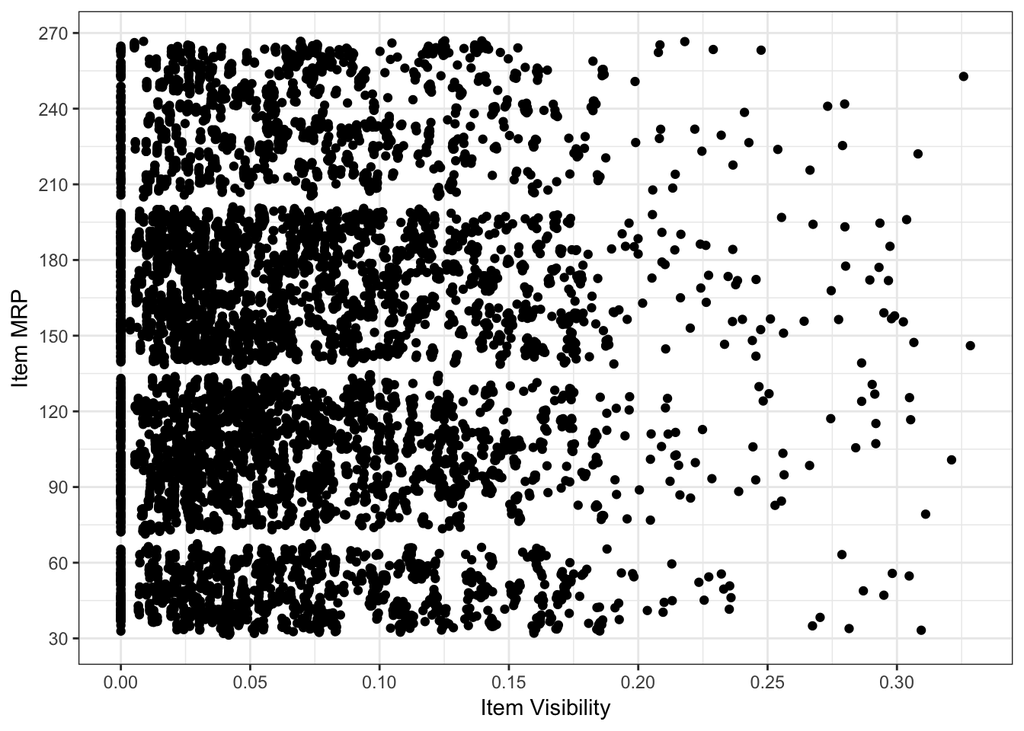

```r
ggplot(marketdata, aes(Item_Visibility, Item_MRP)) + geom_point() + scale_x_continuous("Item Visibility", breaks = seq(0,0.35,0.05))+ scale_y_continuous("Item MRP", breaks = seq(0,270,by = 30))+ theme_bw()
```

```r
#aes = how variables in the data are mapped to visual properties
```

We can even make it more visually clear by creating separate scatter plots for each separate Item_Type:

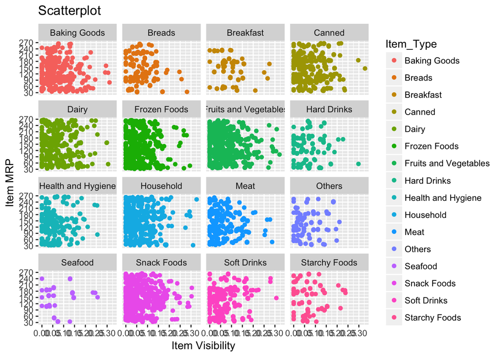

```r
ggplot(marketdata, aes(Item_Visibility, Item_MRP)) +
  geom_point(aes(color = Item_Type)) +
  scale_x_continuous("Item Visibility", breaks = seq(0,0.35,0.05))+
  scale_y_continuous("Item MRP", breaks = seq(0,270,by = 30))+
  labs(title="Scatterplot") + facet_wrap( ~ Item_Type)
```

## Histogram

Histogram is used to plot continuous variable. It breaks the data into different buckets and shows frequency distribution of these buckets.

In this example I used MPG data set, we are going to find the count of cars by manufacturer

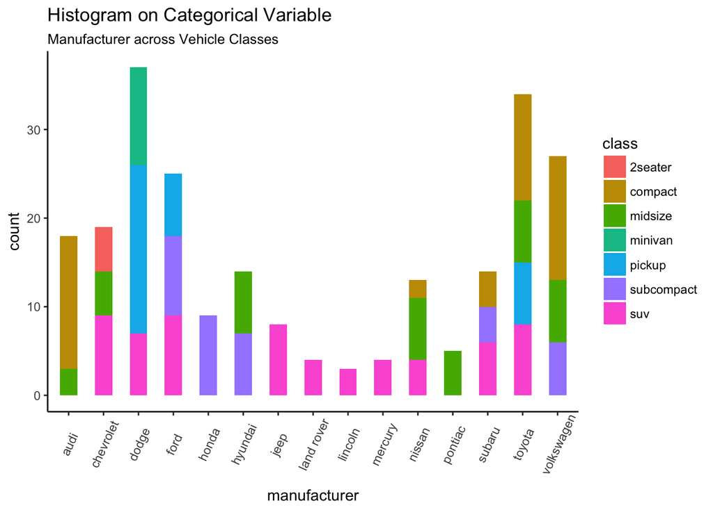

```r
theme_set(theme_classic())

# Histogram on a Categorical variable
g <- ggplot(mpg, aes(manufacturer))
g + geom_bar(aes(fill=class), width = 0.5) +
  theme(axis.text.x = element_text(angle=65, vjust=0.6)) +
  labs(title="Histogram on Categorical Variable",
       subtitle="Manufacturer across Vehicle Classes")
```

## Bar charts

Bar charts are recommended when we want to plot a categorical variable or a combination of continuous and categorical variable.

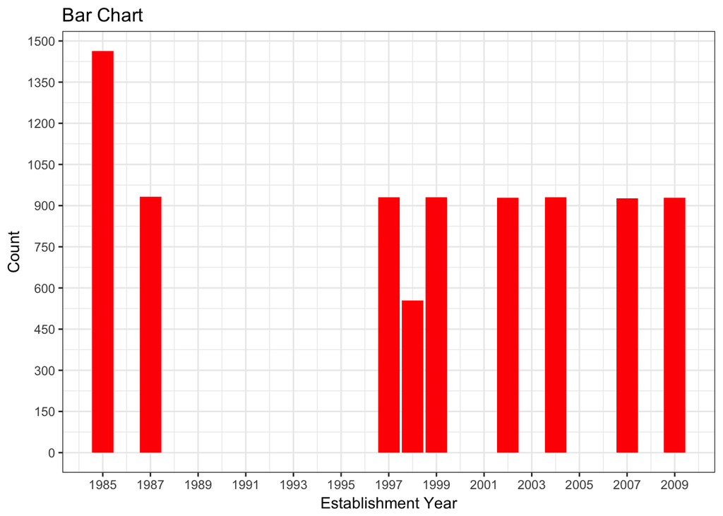

```r
ggplot(marketdata, aes(Outlet_Establishment_Year)) + geom_bar(fill = "red")+theme_bw()+
  scale_x_continuous("Establishment Year", breaks = seq(1985,2010, 2)) +
  scale_y_continuous("Count", breaks = seq(0,1500,150)) +
  labs(title = "Bar Chart")
```

## Box Plot

Box Plots are used to plot a combination of categorical and continuous variables. This plot is useful for visualizing the spread of the data and detect outliers. It shows statistically significant numbers:

The dark line inside the box represents the median

The top of box is 75%ile

bottom of box is 25%ile

From any dataset, if we want to identify important data points including minimum, maximum & median numbers, box plot can be helpful.

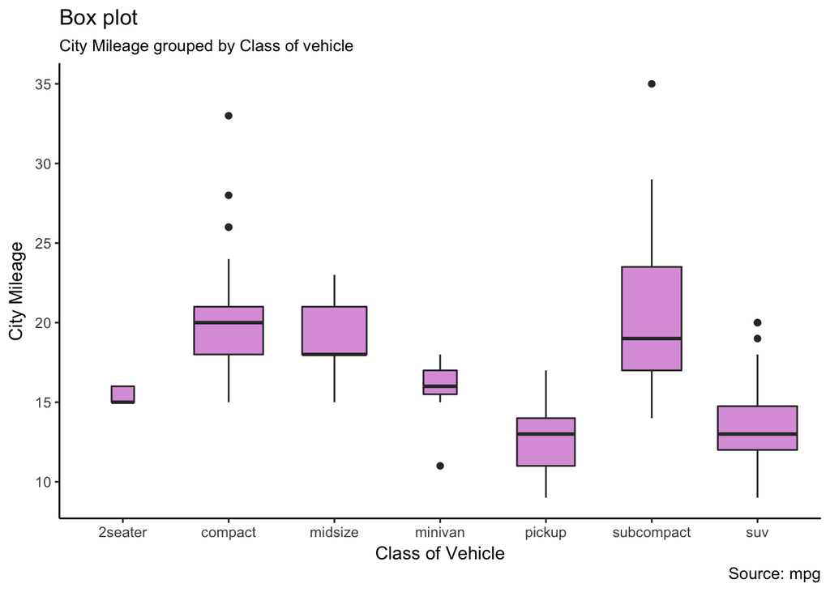

```r
theme_set(theme_classic())

# Plot
g <- ggplot(mpg, aes(class, cty))
g + geom_boxplot(varwidth=T, fill="plum") +
    labs(title="Box plot",
         subtitle="City Mileage grouped by Class of vehicle",
         caption="Source: mpg",
         x="Class of Vehicle",
         y="City Mileage")
```

## Correlogram

Correlogram is used to test the level of co-relation among the variable available in the data set. The cells of the matrix can be shaded or colored to show the co-relation value.

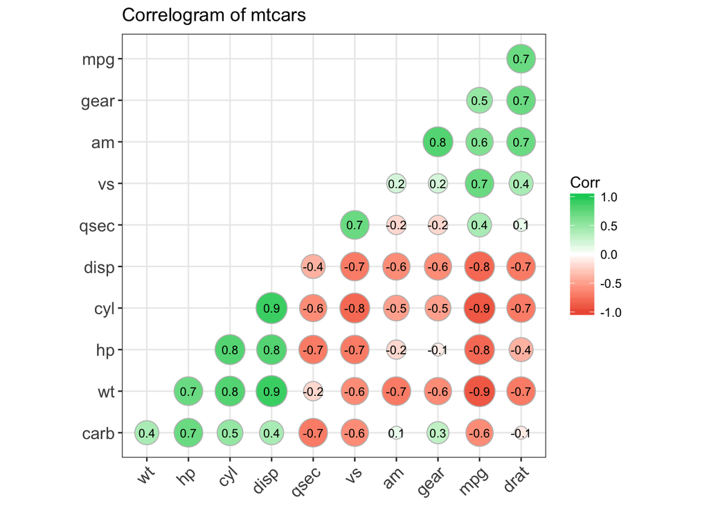

```r
# Correlation matrix
data(mtcars)
corr <- round(cor(mtcars), 1)

# Plot
ggcorrplot(corr, hc.order = TRUE,
           type = "lower",
           lab = TRUE,
           lab_size = 3,
           method="circle",
           colors = c("tomato2", "white", "springgreen3"),
           title="Correlogram of mtcars",
           ggtheme=theme_bw)
```

## Population Pyramid

Population pyramids offer a unique way of visualizing how much population or what percentage of population fall under a certain category. The below pyramid is an excellent example of how many users are retained at each stage of a email marketing campaign funnel.

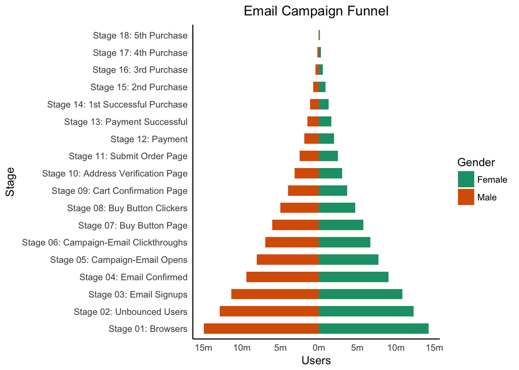

```r
options(scipen = 999)  # turn off scientific notations i.e. 1e+40

# Read data
email_campaign_funnel <- read.csv("https://raw.githubusercontent.com/selva86/datasets/master/email_campaign_funnel.csv")

# X Axis Breaks and Labels
brks <- seq(-15000000, 15000000, 5000000)
lbls = paste0(as.character(c(seq(15, 0, -5), seq(5, 15, 5))), "m")

# Plot
ggplot(email_campaign_funnel, aes(x = Stage, y = Users, fill = Gender)) +   # Fill column
                              geom_bar(stat = "identity", width = .6) +   # draw the bars
                              scale_y_continuous(breaks = brks,   # Breaks
                                                 labels = lbls) + # Labels
                              coord_flip() +  # Flip axes
                              labs(title="Email Campaign Funnel") +
                              theme(plot.title = element_text(hjust = .5),
                                    axis.ticks = element_blank()) +   # Centre plot title
                              scale_fill_brewer(palette = "Dark2")  # Color palette
```

Sources: Data camp R for Data Science https://www.r-bloggers.com https://www.analyticsvidhya.com